# 信州おまつりナビ デプロイマニュアル

## 3.5 データのインポート

[著者のGoogle Drive](https://drive.google.com/file/d/1NzknrWislYBnJg577re3hcGSPq6GaqT1/view?usp=sharing)から、`fesData.sql`をダウンロードする。

Google Driveからダウンロード

[figure not shown]

**ノート**

共有範囲を長野大学内に設定してあるので、大学のGoogleアカウントにログインしてからダウンロードしてほしい。

次に、MySQLに`fesData.sql`のデータを流し込む。

```
bash
```

```bash
docker exec -i shinshu-fesnav-db sh \
    -c 'mysql -u root -p"$MYSQL_PASSWORD" \
    fesData' < "/mnt/c/Users/<Windowsのユーザー名>/Downloads/fesData.sql"
```

**ノート**

`"/mnt/c/Users/<username>/Downloads/fesData.sql"`の部分は、`fesData.sql`のダウンロード先のパスにしてほしい。この時、Windowsの場合は`C:¥...`から始まるパスはWSL内では認識されない（WindowsのファイルシステムはUbuntuにマウントされている状態）なので、`mmt/c/...`から始め、`¥`や`\`は`/`（スラッシュ）に書き換える。

以下のコマンドでデータが書き込まれたか確認する。

**① テーブルの確認**

```
bash
```

```bash
docker exec -it shinshu-fesnav-db sh \
    -c 'mysql -u root -p"$MYSQL_PASSWORD" \
    fesData -e "SHOW TABLES;"'
```

**結果**

```
+-------------------------+
| Tables_in_fesData       |
+-------------------------+
| alembic_version         |
| edit_logs               |
| festival_photos         |
| festivals               |
| information_submissions |
| passkeys                |
| reviews                 |
| user_favorites          |
| users                   |
+-------------------------+
```

**② `festivals`カラム（おまつり情報）の確認**

```
bash
```

```bash
docker exec -it shinshu-fesnav-db sh \
    -c 'mysql -u root -p"$MYSQL_PASSWORD" \
    --default-character-set=utf8mb4 \
    fesData -e "SELECT * FROM festivals;"'
```

**結果**

```
+----+--------------------------------------------------+------------+-----------------------+----------+-----------+------------+-------------+-----------------------------------------------------------------------------------------------------------------------------------------------------------------------+--------+
| id | name                                             | date       | location              | latitude | longitude | attendance | attend_year | description                                                                                                                                                           | access |
+----+--------------------------------------------------+------------+-----------------------+----------+-----------+------------+-------------+-----------------------------------------------------------------------------------------------------------------------------------------------------------------------+--------+
|  2 | 松本ぼんぼん                                     | 2026-08-09 | 松本市                |   36.231 |   137.965 |     200000 |           0 | 松本市の中心市街地で行われる夏祭り。参加連が「ぼんぼん松本ぼんぼんぼん」の曲に合わせて踊り歩く。                                                                      |        |
|  3 | 上田わっしょい                                   | 2026-07-19 | 上田市                |   36.401 |   138.252 |     100000 |           0 | 上田市の夏祭り。生歌・生演奏に合わせて踊るスタイルが特徴。                                                                                                            |        |
|  4 | 善光寺御開帳                                     | 2026-04-01 | 長野市                |  36.6616 |   138.188 |    6000000 |           0 | 数え年で7年に一度、絶対秘仏の御本尊の御身代わり「前立本尊」を本堂にお迎えして行う壮大な行事。                                                                         | NULL   |
|  5 | 御柱祭 (上社山出し)                              | 2026-04-01 | 諏訪市・茅野市        |  35.9912 |    138.13 |     200000 |           0 | 7年に一度、寅と申の年に行われる天下の奇祭。巨木を山から曳き出し、社殿の四隅に建てる。                                                                                 | NULL   |
|  6 | 長野びんずる                                     | 2026-08-02 | 長野市                |  36.6431 |   138.189 |     200000 |           0 | 長野市最大の夏祭り。善光寺の「びんずる尊者」にちなみ、しゃもじを打ち鳴らしながら踊る「びんずる踊り」がメイン。                                                        | NULL   |
|  7 | 諏訪湖祭湖上花火大会                             | 2026-08-15 | 諏訪市                |  36.0477 |   138.113 |     500000 |           0 | 打上数、規模ともに全国屈指の花火大会。四方を山に囲まれた諏訪湖ならではの音響効果も魅力。                                                                              | NULL   |
|  8 | 全国新作花火競技大会                             | 2026-09-06 | 諏訪市                |  36.0477 |   138.113 |     300000 |           0 | 全国の若手花火師が独自の斬新な花火を競う大会。諏訪湖で開催される。                                                                                                    | NULL   |
|  9 | 岡谷太鼓まつり                                   | 2026-08-13 | 岡谷市                |  36.0624 |   138.044 |      50000 |           0 | 300人揃い打ちなど、迫力ある太鼓の演奏が楽しめる祭り。                                                                                                                 | NULL   |
# ...（以下略）
```

**③ `users`カラム（ユーザー情報）の確認**

```
bash
```

```bash
docker exec -it shinshu-fesnav-db sh \
    -c 'mysql -u root -p"$MYSQL_PASSWORD" \
    --default-character-set=utf8mb4 \
    fesData -e "SELECT * FROM users;"'
```

**結果**

```
+----+----------+--------------------------------------------------------------+--------------+--------------------------+----------------+----------+---------------+--------------+
| id | username | password_hash                                                | line_user_id | email                    | google_user_id | is_admin | last_login_at | userID       |
+----+----------+--------------------------------------------------------------+--------------+--------------------------+----------------+----------+---------------+--------------+
|  1 | root     | $2a$12$13ZfcdXbBN8X811TeTTmA.4kXBOcwbBkHnsm975Y3cPVBD2YQwlIO | NULL         | shinshu.fesnav@gmail.com | NULL           |     NULL | NULL          | root         |
|  2 | test     | $2b$12$SE5.R2HCv4r6s.WL9g5rc.r.fII9MXHIA4UVeuSOERoSYW2XrdJdK | NULL         | test@example.com         | NULL           |     NULL | NULL          | test         |
+----+----------+--------------------------------------------------------------+--------------+--------------------------+----------------+----------+---------------+--------------+
```

**ノート**

ユーザーデータは初期状態で以下の通り。

| ユーザー名 | パスワード |
| --- | --- |
| root | `deploy5051` |
| test | `0000` |

## 3.6 自己署名証明書の生成

パスワードやメールアドレスのような機密情報を扱うには接続の暗号化（HTTPS）が必須であり、そのために必要なSSL証明書と秘密鍵は公的な機関が発行するものが必要であるが、動作確認用に[OpenSSL](https://www.openssl.org/)で自己署名証明書を生成することができる。

以下のコマンドで自己署名証明書を生成する。

```
bash
```

```bash
# 証明書の格納ディレクトリの作成
mkdir -p ./certs

# OpenSSLで自己署名証明書を生成
openssl req -new -newkey rsa:2048 -days 365 -nodes -x509 \
    -keyout ./certs/server.key -out ./certs/server.crt
```

このコマンドを実行中にいくつか質問されるが、一般的には以下のように入力する。

**質問内容**

| 項目 | 内容（*必須項目） | 入力例 |
| --- | --- | --- |
| Country Name (2 letter code) | 国名コード* | JP |
| State or Province Name (full name) | 都道府県* | Nagano |
| Locality Name (eg, city) | 市区町村* | Ueda |
| Organization Name (eg, company) | 組織名* | Seki Labo |
| Organizational Unit Name (eg, section) | 部署名・部門名 | Nokura Team |
| Common Name (e.g. server FQDN) | ドメインまたはIPアドレス* | shinshu-fesnav.loca.lt |
| Email Address | メールアドレス* | j22069yn@stu.nagano.ac.jp |

入力が完了すると、`server.crt`（証明書）と`server.key`（秘密鍵）が生成される。`ls -F ./certs`で生成されているかを確認する。

**ヒント自己署名証明書を使用したサイトにアクセスした時の挙動**

自己証明書のサイトに接続するとほぼ全てのブラウザで警告画面が出るが、「このWebサイトを閲覧」や「〜〜にアクセスする（安全ではありません）」などをクリックすると閲覧が可能である。

警告画面（Safari）

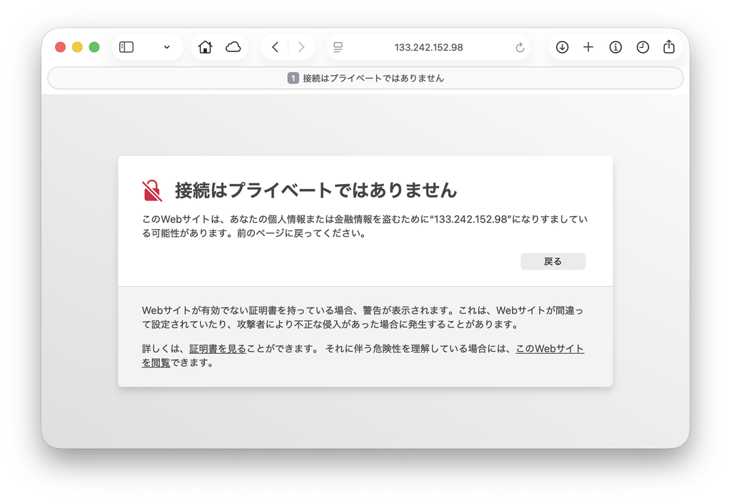

警告画面（Chrome）

[figure not shown]

## 3.7 リバースプロキシの設定

GunicornだけでWebアプリを公開することも技術的には可能だが、実運用においてNginxを前に置く（リバースプロキシ構成にする）のは、**重たい処理や雑務をNginxに任せて、Gunicorn（Python）をアプリの実行だけに集中させる**、のように「分業」させるために重要である。

以下の設定ファイルを`nano`で作成する。

**リバースプロキシ設定ファイル（nginx.conf）**

```
~/shinshu-fesnav/nginx.conf
```

```
user nginx;
worker_processes 1;
pid /tmp/nginx.pid;
error_log /app/logs/nginx_error.log warn;

events {
    worker_connections 1024;
}

http {
    include       /etc/nginx/mime.types;
    default_type  application/octet-stream;

    client_body_temp_path /tmp/client_temp;
    proxy_temp_path       /tmp/proxy_temp;
    fastcgi_temp_path     /tmp/fastcgi_temp;
    uwsgi_temp_path       /tmp/uwsgi_temp;
    scgi_temp_path        /tmp/scgi_temp;

    server {
        listen 5051 ssl default_server;
        server_name shinshu-fesnav.sekilab.org;

        ssl_certificate     /etc/nginx/certs/server.crt;
        ssl_certificate_key /etc/nginx/certs/server.key;

        root /usr/share/nginx/html;
        index index.html;

        access_log /app/logs/nginx_access.log;
        error_log /app/logs/nginx_error.log;

        location /api/ {
            proxy_pass http://127.0.0.1:5052;
            proxy_set_header Host $host;
            proxy_set_header X-Real-IP $remote_addr;
            proxy_set_header X-Forwarded-For $proxy_add_x_forwarded_for;
            proxy_set_header X-Forwarded-Proto https;
            proxy_set_header X-Forwarded-Host $host;

            proxy_redirect off;
        }

        location / {
            try_files $uri $uri/ /index.html;
        }
    }
}
```

保存できたら、`ls -F`で`nginx.conf`が作成されているか確認。

NginxのエンジンはDockerのイメージに含まれており、このファイルは起動時にコンテナにバインドマウントされるため、Nginxのセットアップは割愛する。

## 3.8 サーバープロセスサービスの設定

サーバーの起動にはSystemctlを使用する。通常は管理者ディレクトリにサービスファイルを設置しないといけないが、`--user`オプションをつけることにより、ユーザーディレクトリからの起動が可能になる。

まずはサービスファイルを保存するディレクトリを作成。

```
bash
```

```bash
mkdir -p ~/.config/systemd/user/
cd ~/.config/systemd/user/
```

次に`nano`でサービスファイルを作成。

**サーバープロセスサービス（shinshu-fesnav.service）**

```
~/.config/systemd/user/shinshu-fesnav.service
```

[output not shown]

`ls -F`で`shinshu-fesnav.service`が作成されているか確認。

## 3.9 サーバー本体（NginxとGunicorn）の起動

サーバー本体もスクリプトを用いて起動する。`nano`で以下を作成。

**起動スクリプト（start_server.sh）**

```
~/shinshu-fesnav/start_server.sh
```

```bash
#!/bin/bash

# 設定: インスタンス名とイメージ名
INSTANCE_NAME="shinshu-fesnav"
IMAGE_NAME="server.sif"
SERVICE_NAME="shinshu-fesnav.service"
REPO="yumachin2003/shinshu-fesnav-backend"

# 引数の解析
SKIP_BUILD=false
for arg in "$@"; do
    if [ "$arg" == "--skip-build" ] || [ "$arg" == "-s" ]; then
        SKIP_BUILD=true
    fi
done

echo "--- 🚀 $INSTANCE_NAME のデプロイを開始します ---"

# 0. SIFの準備
if [ "$SKIP_BUILD" = true ]; then
    echo "⏭️  ビルドをスキップします。"
    if [ ! -f "$IMAGE_NAME" ]; then
        echo "❌ エラー: $IMAGE_NAME が見つかりません。ビルドが必要です。"
        exit 1
    fi
else
    echo "🔍 Docker Hub から最新のバックエンドタグを取得中..."
    RESPONSE=$(curl -s -f "https://hub.docker.com/v2/repositories/${REPO}/tags/?page_size=20")

    if [ $? -ne 0 ] || [ -z "$RESPONSE" ]; then
        echo "⚠️  タグの取得に失敗しました。'latest' を使用します。"
        TAG="latest"
    else
        TAG=$(echo "$RESPONSE" | grep -o '"name": *"[^"]*"' | sed 's/"name": *"\([^"]*\)"/\1/' | grep "^v" | sort -V -r | head -n 1)
        [ -z "$TAG" ] && TAG="latest"
    fi
    echo "✨ 使用するタグ: $TAG"

    DOCKER_IMAGE="docker://${REPO}:${TAG}"
    echo "🏗️  Docker イメージを SIF に変換しています ($IMAGE_NAME)..."
    if ! apptainer build --force "$IMAGE_NAME" "$DOCKER_IMAGE"; then
        echo "❌ エラー: SIFの作成に失敗しました。"
        exit 1
    fi
fi

# 1. 必要なディレクトリの準備
mkdir -p logs instance backend/instance

# 2. Systemd サービスを利用した再起動
echo "🔄 Systemd サービスを再起動しています..."

systemctl --user daemon-reload
systemctl --user restart "$SERVICE_NAME"

# 3. 起動確認
if [ $? -eq 0 ]; then
    echo "--- ✅ デプロイ完了 ---"
    echo "HTTPS (5051番ポート) への転送準備が整いました。"
    echo "* \`./show_logs.sh\`でログを確認できます。"
else
    echo "❌ エラー: サービスの起動に失敗しました。"
    exit 1
fi
```

保存できたらスクリプトを実行する。

```
bash
```

```bash
chmod +x ~/shinshu-fesnav/start_server.sh
~/shinshu-fesnav/start_server.sh
```

起動できたら、`lsof -i :5051`で`nginx`のプロセス、`lsof -i :5052`で`gunicorn`のプロセスが動いているか確認する。

ログの確認は以下のコマンドで可能。

```
bash
```

```bash
journalctl --user -u shinshu-fesnav -f -n 10
```

**ヒント**

SIFファイルの作成（サーバーの起動イメージ）には時間がかかるため、`-s`オプションでスキップが可能である。静的ファイル（フロントエンド）の更新後や`.env`や`nginx.conf`、証明書の編集など、サーバーの再起動のみで良い場合にや使用する。

## 3.10 外部への公開（LocalTunnelの利用）

前項でデプロイは完了したが、WSLにはブラウザがないので実際にブラウザからアクセスして確認することができない。そこで、[LocalTunnel](https://theboroer.github.io/localtunnel-www/)を使用することにより、登録不要、コマンド一発でローカルポートのWebサーバーをドメインで簡易的に公開することができる。

LocalTunnelはNode.jsで動作し、パッケージもNode.jsのエコシステムで管理されている（＝`apt`では導入不可）のため、通常は`npm`を利用するが、今回は一時的な確認のために使うため、`npx`というパッケージランナーを使って実行する。

```
bash
```

```bash
npx -y localtunnel -p 5051 -s shinshu-fesnav
```

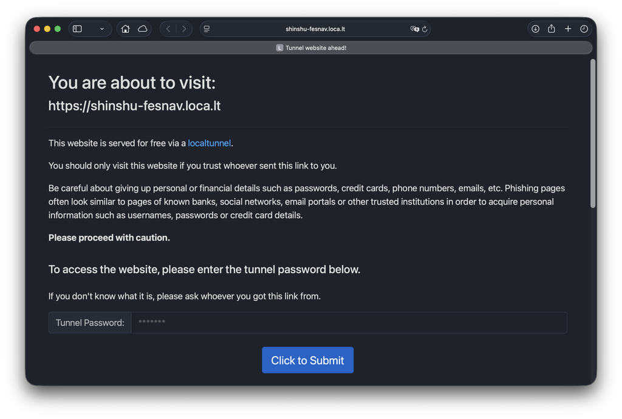

この「Tunnel Password」は、WSLのグローバルIPアドレスを入力すれば良く、以下のコマンドで確認できる。

```
bash
```

```bash
curl inet-ip.info
```

**重要**

LocalTunnelは「トンネル」であるため、`Ctrl+C`でコマンドを終了したりターミナルを閉じたりすると接続が解除される。また、サブドメインは先着なので、他のユーザーに取られる可能性があることにも留意する。

# 4 困った時は

## 4.1 ディレクトリ構成

## 4.2 コマンド集